# fianl_report_music

yongwen

2018年8月1日

# 介紹

這些資料裡包含一些音軌的特徵  
**Spotify’s Top Songs of 2017** 而我試著分析這些音樂背後的特徵

# Read the Data

```r
library(readr)
library(plyr)
library(dplyr)
library(ggplot2)
library(formattable)
library(wordcloud)
library(tm)
library(tidyverse)
daily_spotify <- read_csv('./data.csv')
spotify_data <- read.csv('featuresdf.csv')
```

```r
glimpse(spotify_data)
```

```
## Observations: 100
## Variables: 15
## $ name             <fct> Shape of You, Despacito - Remix, Despacito (F...
## $ artists          <fct> Ed Sheeran, Luis Fonsi, Luis Fonsi, The Chain...
## $ danceability     <dbl> 0.825, 0.694, 0.660, 0.617, 0.609, 0.904, 0.6...
## $ energy           <dbl> 0.652, 0.815, 0.786, 0.635, 0.668, 0.611, 0.5...
## $ key              <int> 1, 2, 2, 11, 7, 1, 0, 6, 1, 0, 11, 2, 5, 3, 2...
## $ loudness         <dbl> -3.183, -4.328, -4.757, -6.769, -4.284, -6.84...
## $ mode             <int> 0, 1, 1, 0, 1, 0, 1, 1, 1, 1, 0, 1, 0, 0, 1, ...
## $ speechiness      <dbl> 0.0802, 0.1200, 0.1700, 0.0317, 0.0367, 0.088...
## $ acousticness     <dbl> 0.581000, 0.229000, 0.209000, 0.049800, 0.055...
## $ instrumentalness <dbl> 0.00e+00, 0.00e+00, 0.00e+00, 1.44e-05, 0.00e...
## $ liveness         <dbl> 0.0931, 0.0924, 0.1120, 0.1640, 0.1670, 0.097...
## $ valence          <dbl> 0.9310, 0.8130, 0.8460, 0.4460, 0.8110, 0.400...
## $ tempo            <dbl> 95.977, 88.931, 177.833, 103.019, 80.924, 150...
## $ duration_ms      <int> 233713, 228827, 228200, 247160, 288600, 17700...
## $ time_signature   <int> 4, 4, 4, 4, 4, 4, 4, 4, 4, 4, 4, 4, 4, 4, 4, ...
```

```r
summary(spotify_data)
```

```
##                        name                artists    danceability
##  1-800-273-8255          : 1   Ed Sheeran      : 4   Min.   :0.2580
##  24K Magic               : 1   The Chainsmokers: 4   1st Qu.:0.6350
##  2U (feat. Justin Bieber): 1   Drake           : 3   Median :0.7140
##  Ahora Dice              : 1   Martin Garrix   : 3   Mean   :0.6968
##  All Night               : 1   Bruno Mars      : 2   3rd Qu.:0.7702
##  Attention               : 1   Calvin Harris   : 2   Max.   :0.9270
##  (Other)                 :94   (Other)         :82
##      energy            key           loudness            mode
##  Min.   :0.3460   Min.   : 0.00   Min.   :-11.462   Min.   :0.00
##  1st Qu.:0.5565   1st Qu.: 2.00   1st Qu.: -6.595   1st Qu.:0.00
##  Median :0.6675   Median : 6.00   Median : -5.437   Median :1.00
##  Mean   :0.6607   Mean   : 5.57   Mean   : -5.653   Mean   :0.58
##  3rd Qu.:0.7875   3rd Qu.: 9.00   3rd Qu.: -4.327   3rd Qu.:1.00
##  Max.   :0.9320   Max.   :11.00   Max.   : -2.396   Max.   :1.00
##
##   speechiness       acousticness      instrumentalness
##  Min.   :0.02320   Min.   :0.000259   Min.   :0.000e+00
##  1st Qu.:0.04312   1st Qu.:0.039100   1st Qu.:0.000e+00
##  Median :0.06265   Median :0.106500   Median :0.000e+00
##  Mean   :0.10397   Mean   :0.166306   Mean   :4.796e-03
##  3rd Qu.:0.12300   3rd Qu.:0.231250   3rd Qu.:1.335e-05
##  Max.   :0.43100   Max.   :0.695000   Max.   :2.100e-01
##
##     liveness          valence           tempo         duration_ms
##  Min.   :0.04240   Min.   :0.0862   Min.   : 75.02   Min.   :165387
##  1st Qu.:0.09828   1st Qu.:0.3755   1st Qu.: 99.91   1st Qu.:198491
##  Median :0.12500   Median :0.5025   Median :112.47   Median :214106
##  Mean   :0.15061   Mean   :0.5170   Mean   :119.20   Mean   :218387
##  3rd Qu.:0.17925   3rd Qu.:0.6790   3rd Qu.:137.17   3rd Qu.:230543
##  Max.   :0.44000   Max.   :0.9660   Max.   :199.86   Max.   :343150
##
##  time_signature
##  Min.   :3.00
##  1st Qu.:4.00
##  Median :4.00
##  Mean   :3.99
##  3rd Qu.:4.00
##  Max.   :4.00
##
```

```r
spotify_data$duration_ms <- round(spotify_data$duration_ms / 1000)
colnames(spotify_data)[15] <- "duration"
```

# 資料分析

## Artists dominating the Top List

用來判定哪些歌手有超過一首歌進入前100名

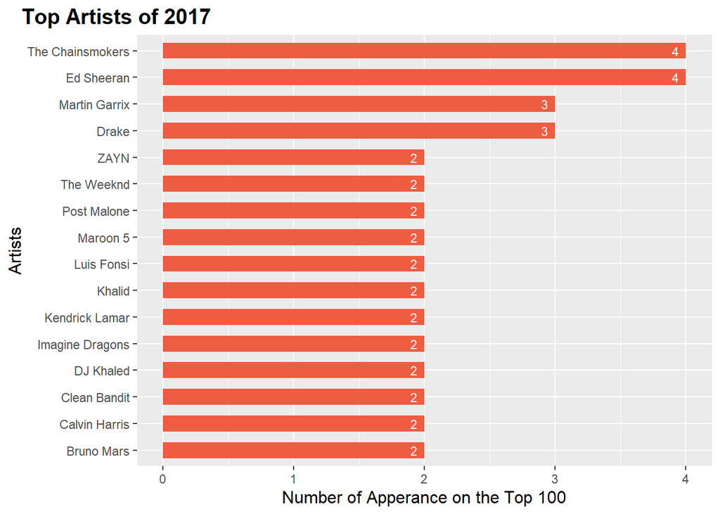

```r
top_artists <- spotify_data %>%
    group_by(artists)  %>%
    summarise(n_apperance = n()) %>%
    filter(n_apperance > 1) %>%
    arrange(desc(n_apperance))

top_artists$artists <- factor(top_artists$artists, levels = top_artists$artists[order(top_artists$n_apperance)]) # in order to visualise the list in descending order

ggplot(top_artists, aes(x = artists, y = n_apperance)) +
    geom_bar(stat = "identity",  fill = "tomato2", width = 0.6 ) +
    labs(title = "Top Artists of 2017", x = "Artists", y = "Number of Apperance on the Top 100") +
    theme(plot.title = element_text(size=15,hjust=-.3,face = "bold"), axis.title = element_text(size=12)) +
    geom_text(aes(label=n_apperance), hjust = 2, size = 3, color = 'white') +
    coord_flip()
```

由此可知，Ed sheeran和The Chainsmokers 有四首不同的歌進入前100名的歌單，而Drake和Martin Garrix有三首不同的歌

```r
ed_sheeran_daily <- daily_spotify %>%
    filter(Region == "us", Artist == "Ed Sheeran", Position <= 100)

formatted_ed <- ed_sheeran_daily %>%
    group_by(`Track Name`) %>%
    summarise(n_daily = n()) %>%
    arrange(desc(n_daily))

formattable(formatted_ed)
```

| Track Name | n_daily |
| --- | --- |
| Shape of You | 364 |
| Perfect | 148 |
| Castle on the Hill | 104 |
| Galway Girl | 62 |
| Perfect Duet (Ed Sheeran & Beyonce) | 39 |
| Happier | 35 |
| Dive | 31 |
| New Man | 22 |
| How Would You Feel (Paean) | 20 |
| What Do I Know? | 19 |
| Barcelona | 17 |
| Supermarket Flowers | 17 |
| Nancy Mulligan | 16 |
| Hearts Don’t Break Around Here | 15 |
| Bibia Be Ye Ye | 14 |
| Eraser | 14 |
| Save Myself | 14 |
| Thinking Out Loud | 6 |
| Photograph | 5 |

## 變數間的關聯

運用 `corrplot` function 去作圖分析

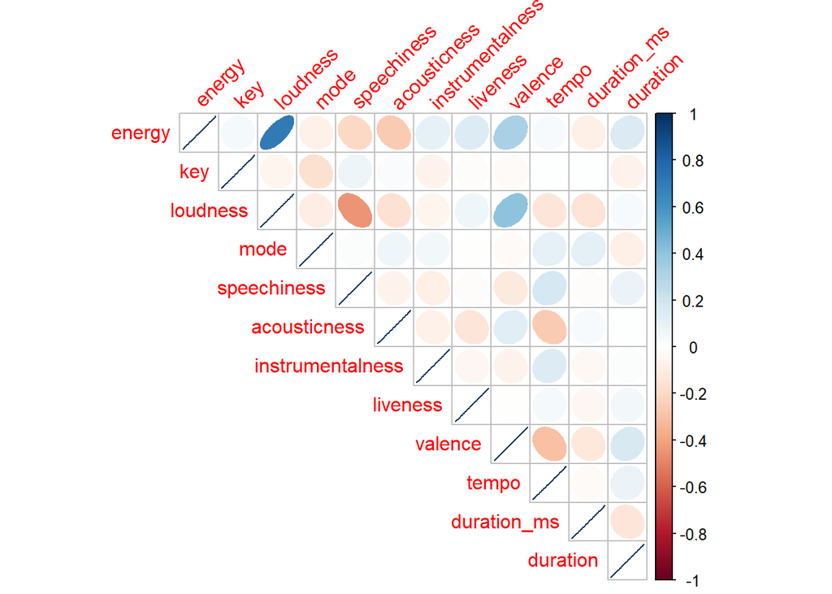

```r
library(corrplot)
spotify_data_num <- spotify_data[,-(1:3)]
mtCor <- cor(spotify_data_num)
corrplot(mtCor, method = "ellipse", type = "upper", tl.srt = 45)
```

## Top songs的普遍特徵

### 常用的音頻或曲調keys

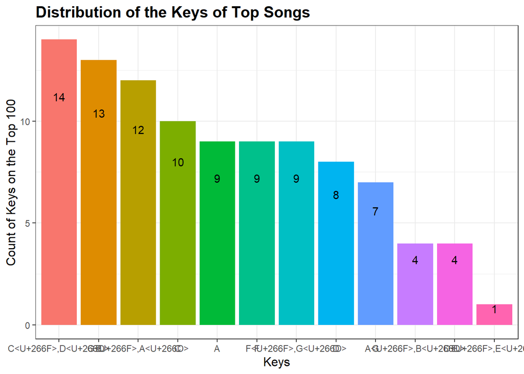

```r
spotify_data$key <- as.character(spotify_data$key)
spotify_data$key <- revalue(spotify_data$key, c("0" = "C", "1" = "C♯,D♭", "2" = "D", "3" = "D♯,E♭", "4" = "E", "5" =  "F", "6" = "F♯,G♭","7" = "G","8" = "G♯,A♭","9" = "A","10" = "A♯,B♭","11" = "B"))

song_keys <- spotify_data %>%
    group_by(key) %>%
    summarise(n_key = n()) %>%
    arrange(desc(n_key))

song_keys$key <- factor(song_keys$key, levels = song_keys$key[order(song_keys$n_key)]) # in order to visualise the keys in descending order

ggplot(song_keys, aes(x = reorder(key,-n_key), y = n_key, fill = reorder(key,-n_key))) +
    geom_bar(stat = "identity") +
    labs(title = "Distribution of the Keys of Top Songs", x = "Keys", y = "Count of Keys on the Top 100") +
    geom_text(aes(label=n_key), position = position_stack(vjust = 0.8)) +
    theme_bw() +
    theme(plot.title = element_text(size=15,face = "bold"), axis.title = element_text(size=12)) +
    theme(legend.position="none")
```

由此可知常用的曲調是 **C♯,D♭**; 反之最不常用的是**D♯,E♭**

### Density Plots of Correlated Variables

我們已經知道 `energy`,`valence` and `danceability` 呈現正相關; 但我們還想知道這些變數呈現多少在於我們前100名首歌之中

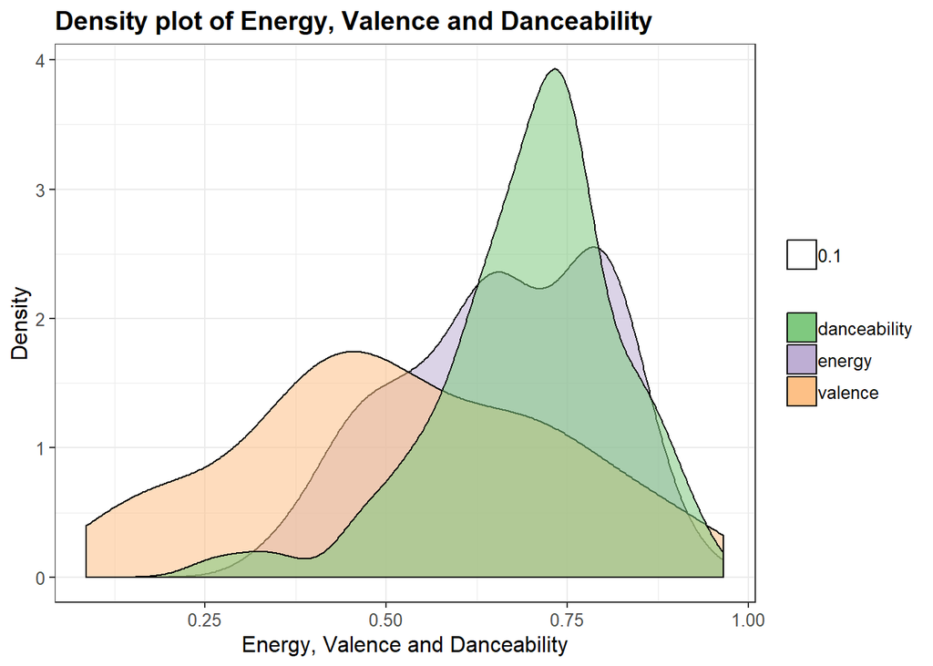

```r
correlated_density <- ggplot(spotify_data) +
    geom_density(aes(energy, fill ="energy", alpha = 0.1)) +
    geom_density(aes(valence, fill ="valence", alpha = 0.1)) +
    geom_density(aes(danceability, fill ="danceability", alpha = 0.1)) +
    scale_x_continuous(name = "Energy, Valence and Danceability") +
    scale_y_continuous(name = "Density") +
    ggtitle("Density plot of Energy, Valence and Danceability") +
    theme_bw() +
    theme(plot.title = element_text(size = 14, face = "bold"),
          text = element_text(size = 12)) +
    theme(legend.title=element_blank()) +
    scale_fill_brewer(palette="Accent")

correlated_density
```

這些變數被限制在(0,1)之中，呈現正相關

# 介紹

The Top Spotify Tracks of 2017 dataset contains 100 the most popular songs, we will try to analyze the data see if we can find out what are the secret ingradients(Tempo, Keys, name) to make a song popular.

Danceability describes how suitable a track is for dancing,0.0 is least danceable and 1.0 is most danceable.

Energy is a measure from 0.0 to 1.0 and represents a perceptual measure of intensity and activity.

Speechiness detects the presence of spoken words in a track. Values above 0.66 describe tracks that are probably made entirely of spoken words.

acousticness :A confidence measure from 0.0 to 1.0 of whether the track is acoustic

liveness: Higher liveness values represent an increased probability that the track was performed live.

valence: A measure from 0.0 to 1.0 describing the musical positiveness conveyed by a track. Tracks with high valence sound more positive (e.g. happy, cheerful, euphoric),

```r
spotify_data <- read.csv('featuresdf.csv')
spotify_data$danceability<- spotify_data$danceability*100
spotify_data$energy<- spotify_data$energy*100
spotify_data$speechiness<- spotify_data$speechiness*100
spotify_data$acousticness<- spotify_data$acousticness*100
spotify_data$instrumentalness<- spotify_data$instrumentalness*100
spotify_data$liveness<- spotify_data$liveness*100
spotify_data$valence<- spotify_data$valence*100
```

### Data preparation

- Key :The key the track is in. Integers map to pitches using standard Pitch Class notation. E.g. 0 = C, 1 = C sharp/D flat, 2 = D, and so on.
- Mode : Major is represented by 1 and minor is 0.

Key Characterstics and Mood

- C major :Innocently Happy
- C minor :Innocently Sad, Love-Sick
- C sharp minor : Despair, Wailing, Weeping
- C sharp major: fullness, sonorousness, euphony
- D major: Triumphant, Victorious War-Cries
- D minor: Serious, Pious, Ruminating
- D sharp minor: Deep Distress, Existential Angst
- D sharp major: Cruel, Hard, Yet Full of Devotion
- E major: Quarrelsome, Boisterous, Incomplete Pleasure
- E minor: Effeminate, Amorous, Restless
- F major: Complaisance and calm
- E sharp minor: Obscure, Plaintive, Funereal
- F sharp major : Conquering Difficulties, Sighs of Relief
- F sharp minor: Gloomy, Passionate Resentment
- G major: Serious, Magnificent, Fantasy
- G minor: Discontent, Uneasiness
- G sharp major : Death, Eternity, Judgement
- G sharp minor : Grumbling, Moaning, Wailing
- A major : Joyful, Pastoral, Declaration of Love
- A minor : Tender, Plaintive, Pious
- A sharp major: Joyful, Quaint, Cheerful
- Bflat minor : Terrible, the Night, Mocking
- B major: Harsh, Strong, Wild, Rage
- B minor: Solitary, Melancholic, Patience

```r
spotify_data$tone <- ifelse(spotify_data$mode==0, "minor", "major")

spotify_data$scale <-ifelse (spotify_data$key==0, "C",
                      ifelse(spotify_data$key==1, "C#",
                             ifelse(spotify_data$key==2, "D",
                               ifelse(spotify_data$key==3,"D#" ,
                                      ifelse(spotify_data$key==4, "E",
                                             ifelse(spotify_data$key==5, "E#",
                                                    ifelse(spotify_data$key==6,"F",
                                                           ifelse(spotify_data$key==7, "F#",
                                                                  ifelse(spotify_data$key==8, "G",
                                                                         ifelse(spotify_data$key==9,"G#",
                                                                                ifelse(spotify_data$key==10,"A",
                                                                                       "A#")))))))))))


spotify_data$keys <- paste(spotify_data$scale, spotify_data$tone, sep= " ")

spotify_data$keysign <- ifelse (spotify_data$keys %in% c("C major","A minor" ), "Original",
                         ifelse(spotify_data$keys %in% c("G major","E minor","D# minor" ), "F sharp",
                          ifelse(spotify_data$keys %in% c("D major","B minor" ), "F,C Sharp",
                            ifelse(spotify_data$keys %in% c("A major","F# minor" ), "F,C,G Sharp",
                            ifelse(spotify_data$keys %in% c("E major","C# minor" ), "F,A,G,D Sharp",
                            ifelse(spotify_data$keys %in% c("B major","G# minor" ), "F,C,G,D,A Sharp",
                            ifelse(spotify_data$keys %in% c("F# major","G# minor" ), "F,A,C,G,D,A,E Sharp",
                             ifelse(spotify_data$keys %in% c("C# major","A# minor" ), "F,A,C,G,D,A,E,B Sharp",
                             ifelse(spotify_data$keys %in% c("F major","D minor","E# major" ), "B Flat",
                              ifelse(spotify_data$keys %in% c("G minor", "A# major" ), "B,E Flat",
                               ifelse(spotify_data$keys %in% c("C minor","D# major"), "B,E, A Flat",
                               ifelse(spotify_data$keys %in% c("F minor","G# major","E# minor" ), "B,A,D,E Flat",
                              "Unknown"))))))))))))


spotify_data$keylabel <- ifelse(spotify_data$keys== "C major",  "C major :Innocently Happy",
                  ifelse (spotify_data$keys=="C minor", "C minor :Innocently Sad, Love-Sick",
                  ifelse(spotify_data$keys=="C# minor" , "C sharp minor : Despair, Wailing, Weeping",
                   ifelse(spotify_data$keys=="C# major","C sharp major: Fullness, Sonorousness, Euphony",
                  ifelse(spotify_data$keys=="D major", "D major: Triumphant, Victorious War-Cries",
                  ifelse(spotify_data$keys=="D minor", "D minor: Serious, Pious, Ruminating",
                   ifelse(spotify_data$keys=="D# minor", "D sharp minor: Deep Distress, Existential Angst",
                   ifelse(spotify_data$keys=="D# major", "Cruel, Hard, Yet Full of Devotion",
                   ifelse(spotify_data$keys=="E major", "E major: Quarrelsome, Boisterous, Incomplete Pleasure",
                    ifelse(spotify_data$keys=="E minor", "E minor: Effeminate, Amorous, Restless",
                    ifelse(spotify_data$keys %in% c("E# major" ,"F major"), "F major: Complaisance and calm",
                    ifelse(spotify_data$keys %in% c("F minor", "E# minor"),  "F minor: Obscure, Plaintive, Funereal",
                    ifelse(spotify_data$keys=="F# major", "F sharp major : Conquering Difficulties, Sighs of Relief",
                    ifelse(spotify_data$keys=="F# minor", "F sharp minor: Gloomy, Passionate Resentment",
                    ifelse(spotify_data$keys=="G major", "G major: Serious, Magnificent, Fantasy",
                    ifelse(spotify_data$keys=="G minor", "G minor: Discontent, Uneasiness",
                    ifelse(spotify_data$keys=="G# major", "G sharp major : Death, Eternity, Judgement",
                    ifelse(spotify_data$keys=="G# minor", "G sharp minor: Grumbling, Moaning, Wailing",
                    ifelse(spotify_data$keys=="A major", "A major : Joyful, Pastoral, Declaration of Love",
                    ifelse(spotify_data$keys=="A minor", "A minor : Tender, Plaintive, Pious",
                    ifelse (spotify_data$keys=="A# major", "A sharp major: Joyful, Quaint, Cheerful",
                    ifelse(spotify_data$keys=="A# minor", "A sharp minor: Terrible, the Night, Mocking",
                           "Unknown")  )))))))      )))       )))))))))))



# tempo classification
spotify_data$tempoc[spotify_data$tempo >= 66 & spotify_data$tempo <76] <- "Adagio"
spotify_data$tempoc[spotify_data$tempo >=  76 & spotify_data$tempo <108] <- "Andante"
spotify_data$tempoc[spotify_data$tempo >= 108 & spotify_data$tempo <120] <- "Moderato"
spotify_data$tempoc[spotify_data$tempo >= 120 &spotify_data$tempo <156 ] <- "Allegro"
spotify_data$tempoc[spotify_data$tempo >= 156 & spotify_data$tempo <176] <- "Vivace"
spotify_data$tempoc[spotify_data$tempo >= 176 ] <- "Presto"


spotify_data$tlabel[spotify_data$tempo >= 66 & spotify_data$tempo <76] <-" 66- 76"
spotify_data$tlabel[spotify_data$tempo >=  76 & spotify_data$tempo <108] <- "76-108"
spotify_data$tlabel[spotify_data$tempo >= 108 & spotify_data$tempo <120] <- "108- 120"
spotify_data$tlabel[spotify_data$tempo >= 120 & spotify_data$tempo <156 ] <- "120 -156"
spotify_data$tlabel[spotify_data$tempo >= 156 & spotify_data$tempo <176] <- "156-176"
spotify_data$tlabel[spotify_data$tempo >= 176 ] <- "> 176"
```

# Analysis on 100 Top song tracks

## Most Popular Songs

Then we show the artists has most songs. We group the artists with 1, 2, 3 or 4 song on the billboard. Then we run a comparison to see what are the differences of the average score of different aspects of a song. As we can see the average scores, dispite how many songs an artists has in top 100, they all tends to focus more on the energy, danceability, and valences of a song. Personally, I think it is quite interesting, because in Chinese music Speechiness or lyrics is a very important index for a popular song.

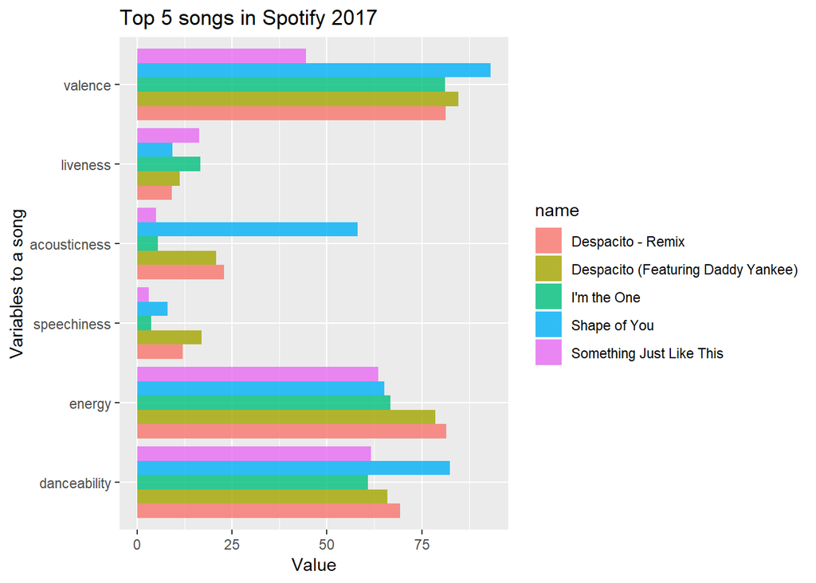

```r
# Top 5 Songs
m5 <- spotify_data[c(1:5),]
m5<- m5[, c(1,3,4,8,9,11,12)]
m5<- as.data.frame(m5)
m5.long <- melt(m5, id.vars="name")

mp1<- ggplot(data=m5.long, aes(x=variable, y=value))+geom_bar(aes(y=value, fill=name),stat="identity", alpha=0.8 , position="dodge")+ ylab("Value")+ xlab("Variables to a song")+coord_flip()+ggtitle("Top 5 songs in Spotify 2017 ")
mp1
```

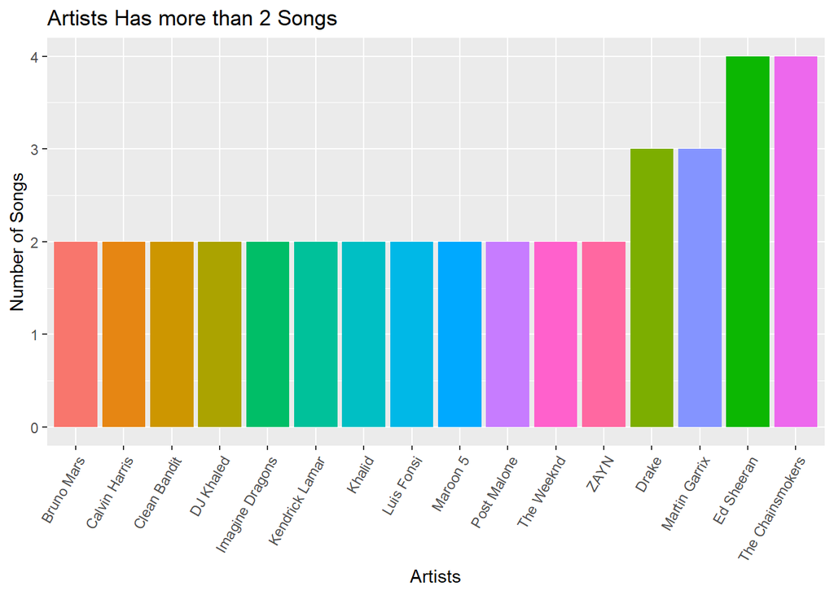

```r
# Top artists
a1 <- group_by(spotify_data, artists )
a2 <- dplyr::summarise(a1,  count=n())
a2 <- arrange(a2, desc(count))
a3 <- filter(a2, count>1)

# Graph the artists have more than 2 songs
ap1 <- ggplot(a3, aes(x=reorder(artists,count),y=count))+
  geom_bar(aes(y=count,fill=artists), stat="identity")+
  labs(x="Artists", y="Number of Songs",
       title="Artists Has more than 2 Songs")+ theme(legend.position="none", axis.text.x = element_text(angle = 60, hjust = 1))
ap1
```

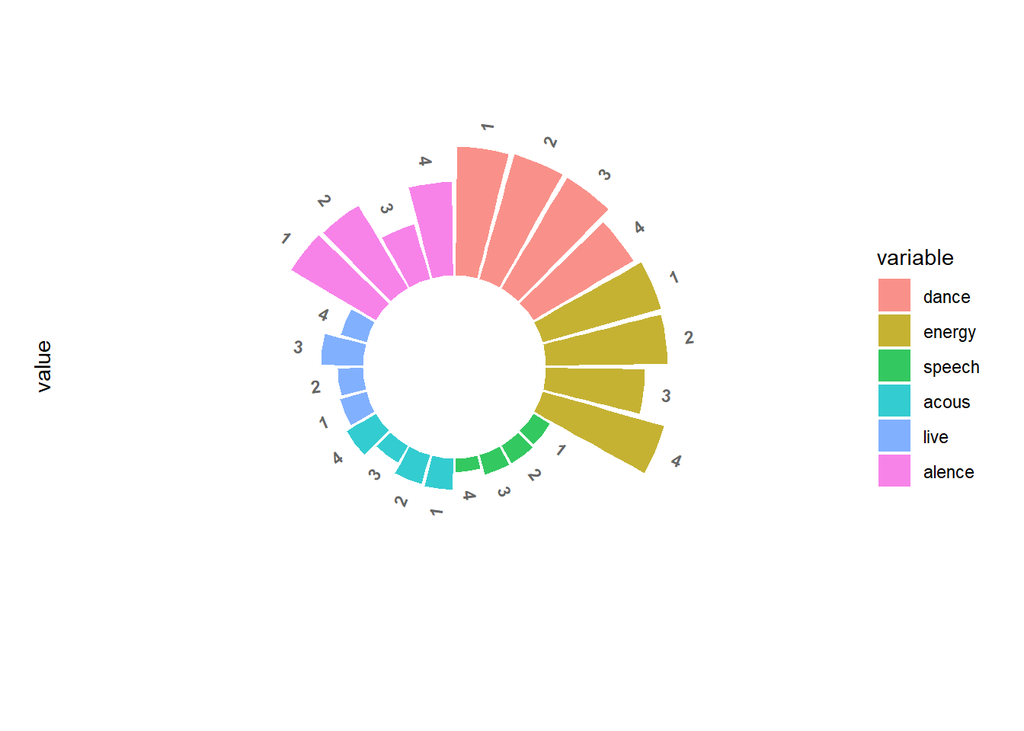

```r
# the differences between 1,2,3,4 song artisits
a4<- merge (spotify_data, a2, x.by=artists)
a5 <- group_by(a4, count)
a6 <- summarise(a5,
                   dance= mean(danceability), energy=mean(energy),  speech=mean(speechiness),acous= mean(acousticness) , live=mean(liveness) ,alence=mean(valence))

# reshape it to the long format
a66<- as.data.frame(a6)
a66.long <- melt(a66, id.vars="count")
a66.long <- a66.long[with(a66.long, order(variable)),]



#circle bar plot
mdata1 <- a66.long
mdata1$id=seq(1, nrow(mdata1))
mlabel_data1=mdata1
mnumber_of_bar1=nrow(mlabel_data1)
angle1m= 90 - 360 * (mlabel_data1$id-0.5) /mnumber_of_bar1
mlabel_data1$hjust<-ifelse( angle1m < -90, 1, 0)
mlabel_data1$angle<-ifelse(angle1m < -90, angle1m+180, angle1m)

mp <- ggplot(mdata1, aes(x=as.factor(id), y=value, fill=variable))+geom_bar(stat="identity", alpha=0.8) + ylim(-50,120)+theme_minimal()+theme(
    axis.text = element_blank(),
    panel.grid = element_blank(),
    plot.margin = unit(rep(-1,6), "cm")  ) +
  coord_polar()+
  geom_text(data=mlabel_data1, aes(x=id, y=value+10, label=count, hjust=hjust), color="black", fontface="bold",alpha=0.6, size=3, angle= mlabel_data1$angle, inherit.aes = FALSE ) + ggtitle("d")

mp
```

## Individual Player analysis

We will see the radarchart of artists who has more then two songs.

### Ed sheeran

Ed sheeran demonstrated a substantial diversity abilities in his songs. Especially Shape Of You, the tension is presented in various aspects.

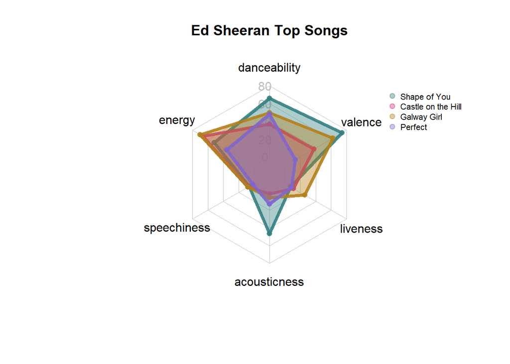

```r
tsong1 <- filter(spotify_data, artists %in% c("Ed Sheeran"))
tsong2<-  tsong1[,c(1,3,4,8,9,11,12)]


# radar chart
rownames(tsong2)=tsong2$name
tsong3 <- tsong2[,  c(2,3,4,5,6,7)]
data=rbind(rep(100,6) , rep(0,6) , tsong3)


colors_border=c( rgb(0.2,0.5,0.5,0.9), rgb(0.8,0.2,0.5,0.9) , rgb(0.7,0.5,0.1,0.9), rgb(0.5,0.4,0.8,0.9) )
colors_in=c( rgb(0.2,0.5,0.5,0.4), rgb(0.8,0.2,0.5,0.4) , rgb(0.7,0.5,0.1,0.4) , rgb(0.5,0.4,0.8,0.4))
radarchart( data  , axistype=1 ,
    #custom polygon
    pcol=colors_border , pfcol=colors_in , plwd=4 , plty=1,
    #custom the grid
    cglcol="grey", cglty=1, axislabcol="grey", caxislabels=seq(0,100,20), cglwd=0.5,
    #custom labels
    vlcex=1 , title="Ed Sheeran Top Songs"
    )
legend(x=1.3, y=1.0, legend = rownames(data[-c(1,2),]), bty = "n", pch=20 , col=colors_in , text.col = "black", cex=0.7, pt.cex=1.5)
```

### The Chainsmokers

Chainsmoker’s songs emphasiszed in energy and danceability.

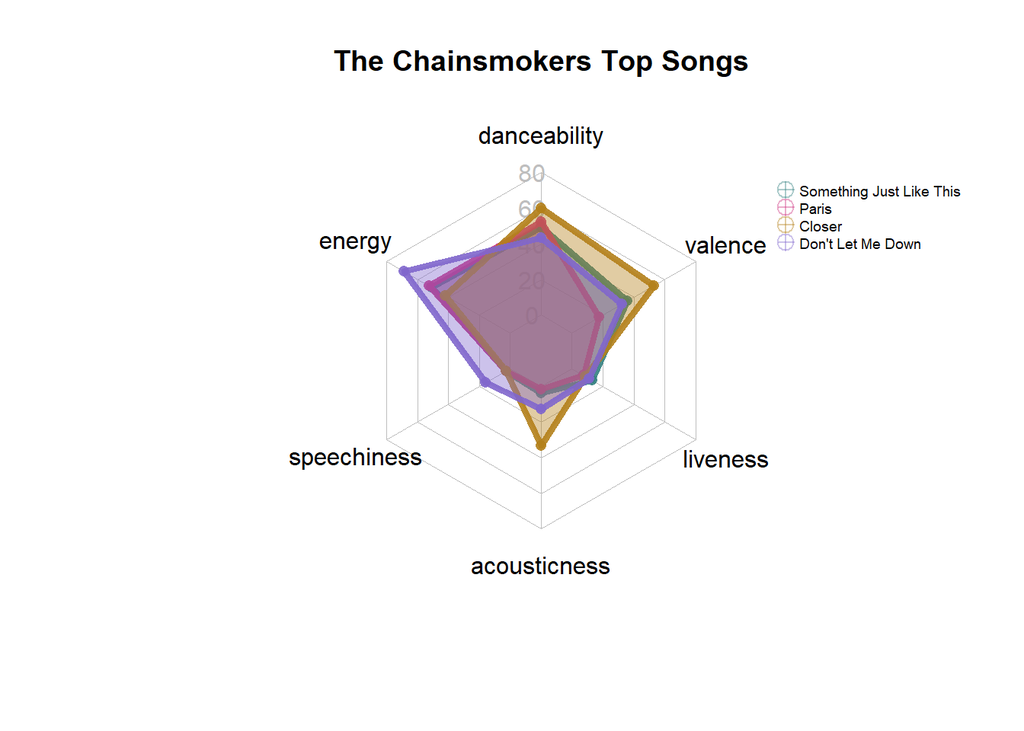

```r
tsong11 <- filter(spotify_data, artists %in% c("The Chainsmokers"))
tsong21<-  tsong11[, c(1,3,4,8,9,11,12)]


# radar chart
rownames(tsong21)=tsong21$name
tsong31 <- tsong21[, c(2,3,4,5,6,7)]
data1=rbind(rep(100,6) , rep(0,6) , tsong31)


colors_border=c( rgb(0.2,0.5,0.5,0.9), rgb(0.8,0.2,0.5,0.9) , rgb(0.7,0.5,0.1,0.9), rgb(0.5,0.4,0.8,0.9) )
colors_in=c( rgb(0.2,0.5,0.5,0.4), rgb(0.8,0.2,0.5,0.4) , rgb(0.7,0.5,0.1,0.4) , rgb(0.5,0.4,0.8,0.4))
radarchart( data1  , axistype=1 ,
    #custom polygon
    pcol=colors_border , pfcol=colors_in , plwd=4 , plty=1,
    #custom the grid
    cglcol="grey", cglty=1, axislabcol="grey", caxislabels=seq(0,100,20), cglwd=0.5,
    #custom labels
    vlcex=1 , title="The Chainsmokers Top Songs"
    )
legend(x=1.3, y=1.0, legend = rownames(data1[-c(1,2),]), bty = "n", pch=10 , col=colors_in , text.col = "black", cex=0.6, pt.cex=1.5)
```

### Drake

Drake’s work definitely focus on danceability

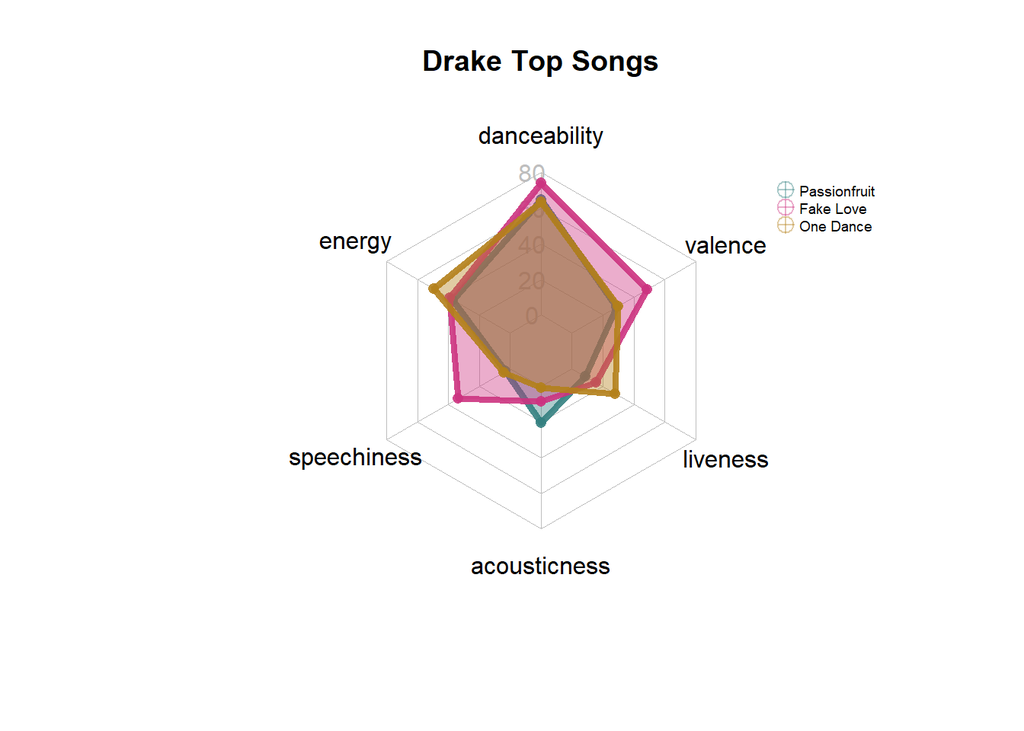

```r
tsong13 <- filter(spotify_data, artists %in% c("Drake"))
tsong23<-  tsong13[, c(1,3,4,8,9,11,12)]


# radar chart
rownames(tsong23)=tsong23$name
tsong33 <- tsong23[, c(2,3,4,5,6,7)]
data3=rbind(rep(100,6) , rep(0,6) , tsong33)


colors_border=c( rgb(0.2,0.5,0.5,0.9), rgb(0.8,0.2,0.5,0.9) , rgb(0.7,0.5,0.1,0.9))
colors_in=c( rgb(0.2,0.5,0.5,0.4), rgb(0.8,0.2,0.5,0.4) , rgb(0.7,0.5,0.1,0.4))
 radarchart( data3  , axistype=1 ,
    #custom polygon
    pcol=colors_border , pfcol=colors_in , plwd=4 , plty=1,
    #custom the grid
    cglcol="grey", cglty=1, axislabcol="grey", caxislabels=seq(0,100,20), cglwd=0.5,
    #custom labels
    vlcex=1 , title="Drake Top Songs"
    )
legend(x=1.3, y=1.0, legend = rownames(data3[-c(1,2),]), bty = "n", pch=10 , col=colors_in , text.col = "black", cex=0.6, pt.cex=1.5)
```

### Martin Garrix

Martin’s tracks are very interstering, his songs almost have showed an identical distribution. we can see his liveness is quite strong.

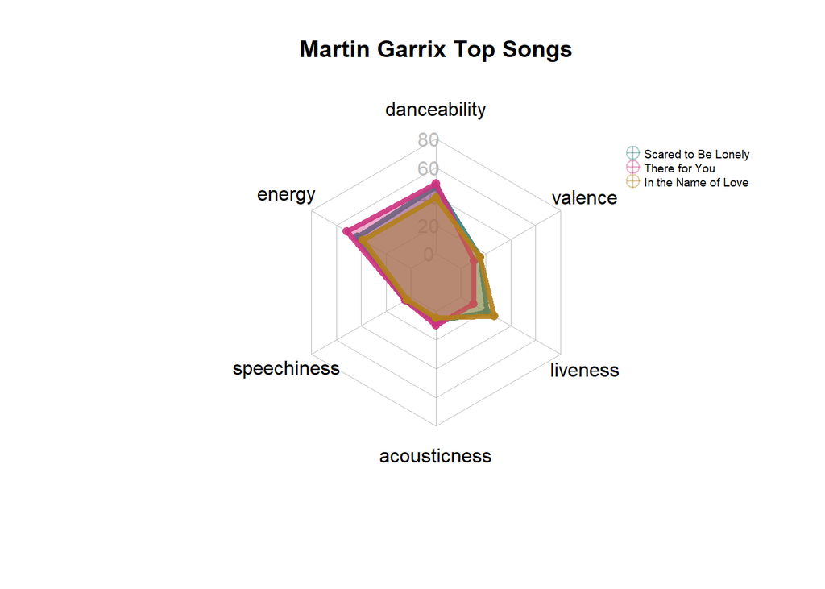

```r
tsong14 <- filter(spotify_data, artists %in% c("Martin Garrix"))
tsong24<-  tsong14[, c(1,3,4,8,9,11,12)]


# radar chart
rownames(tsong24)=tsong24$name
tsong34 <- tsong24[, c(2,3,4,5,6,7)]
data4=rbind(rep(100,6) , rep(0,6) , tsong34)


colors_border=c( rgb(0.2,0.5,0.5,0.9), rgb(0.8,0.2,0.5,0.9) , rgb(0.7,0.5,0.1,0.9))
colors_in=c( rgb(0.2,0.5,0.5,0.4), rgb(0.8,0.2,0.5,0.4) , rgb(0.7,0.5,0.1,0.4))
radarchart( data4  , axistype=1 ,
    #custom polygon
    pcol=colors_border , pfcol=colors_in , plwd=4 , plty=1,
    #custom the grid
    cglcol="grey", cglty=1, axislabcol="grey", caxislabels=seq(0,100,20), cglwd=0.5,
    #custom labels
    vlcex=1 , title="Martin Garrix Top Songs"
    )
legend(x=1.3, y=1.0, legend = rownames(data4[-c(1,2),]), bty = "n", pch=10 , col=colors_in , text.col = "black", cex=0.6, pt.cex=1.5)
```

## Tonality of Top 100 songs

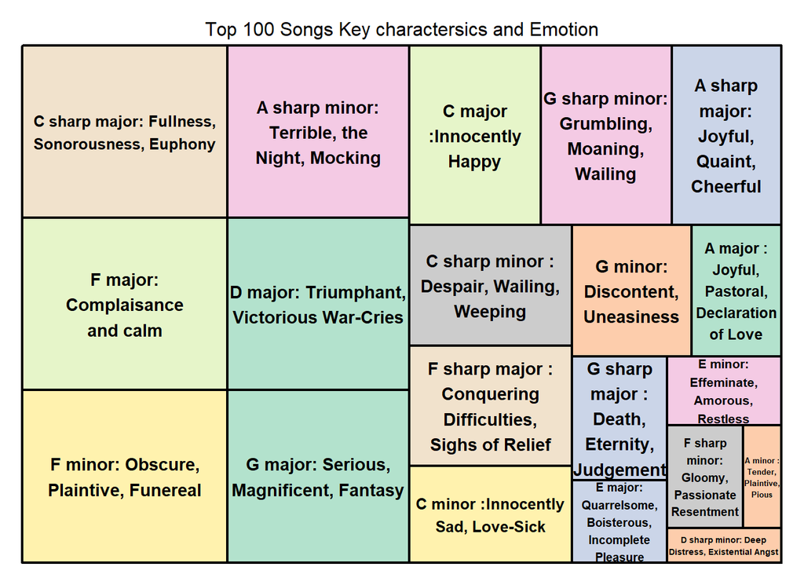

```r
tone1 <- group_by(spotify_data, keylabel )
tone2 <- dplyr::summarise(tone1,  count=n())
tone2 <- arrange(tone2, desc(count))


# Tonality treemap
treemap(tone2, index="keylabel", vSize="count", type="index",
        palette="Pastel2", title="Top 100 Songs Key charactersics and Emotion", fontsize.title=12)
```

## Major vs Minor

We can see more songs use Major chords indeed.

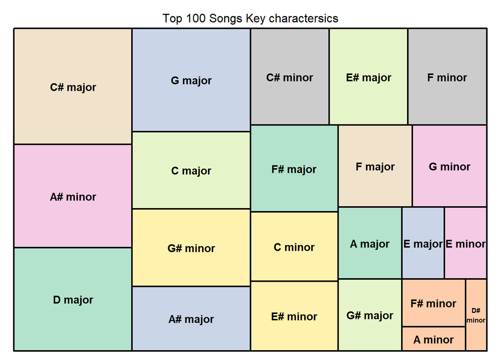

```r
ctone1 <- group_by(spotify_data, keys )
ctone2 <- dplyr::summarise(ctone1,  count=n())
ctone2 <- arrange(ctone2, desc(count))


# Tonality treemap
treemap(ctone2, index="keys", vSize="count", type="index",
        palette="Pastel2", title="Top 100 Songs Key charactersics", fontsize.title=12)
```

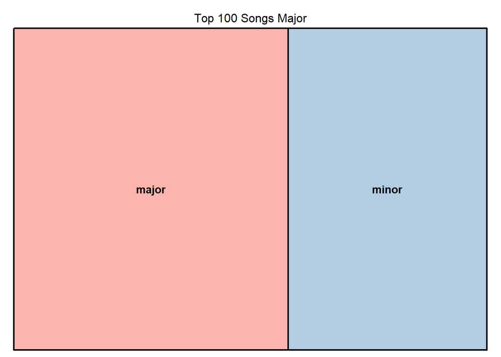

```r
# major vs Minor
major <- group_by(spotify_data, tone )
major2 <- dplyr::summarise(major,  count=n())

# Major treemap
treemap(major2, index="tone", vSize="count", type="index",
        palette="Pastel1", title="Top 100 Songs Major", fontsize.title=12)
```

# Key signature analysis

## Emotion with Key signature

From the graph, we can see more than 15 songs used C# major and A# minor, which means F,A,C,G,D,A,B sharp. Im quite surprised the popular songs used such complicated key signatures.

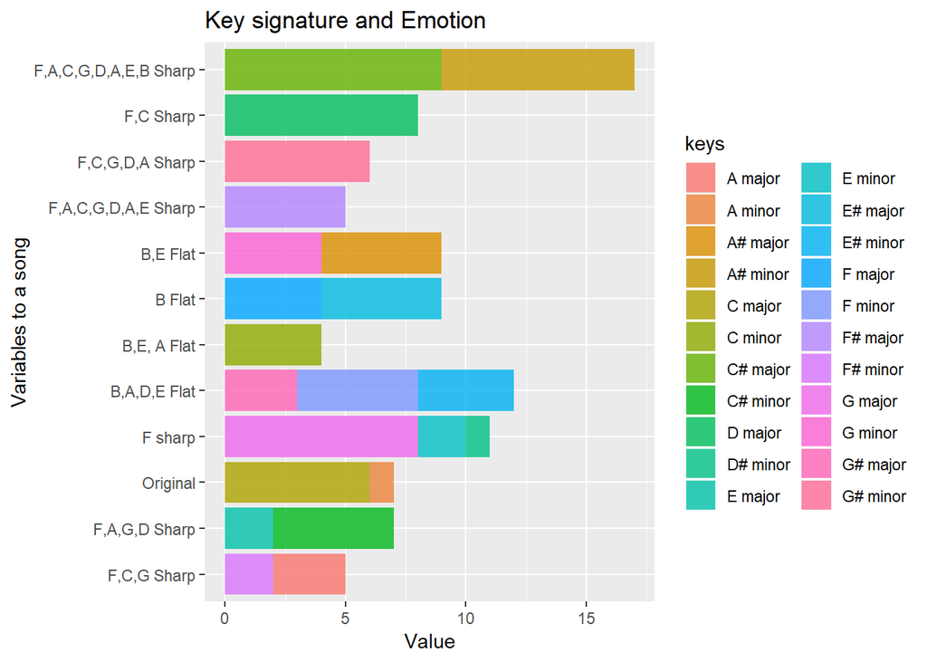

```r
keystone1 <- group_by(spotify_data, keysign, keys )
keystone2 <- dplyr::summarise(keystone1,  count=n())
keystone2 <- arrange(keystone2, desc(count))

keysp1<- ggplot(data=keystone2, aes(x=reorder(keysign,count), y=count))+geom_bar(aes(y=count, fill=keys),stat="identity", alpha=0.8 )+ ylab("Value")+ xlab("Variables to a song")+coord_flip()+ggtitle("Key signature and Emotion")
keysp1
```

## What key signiture uses the most

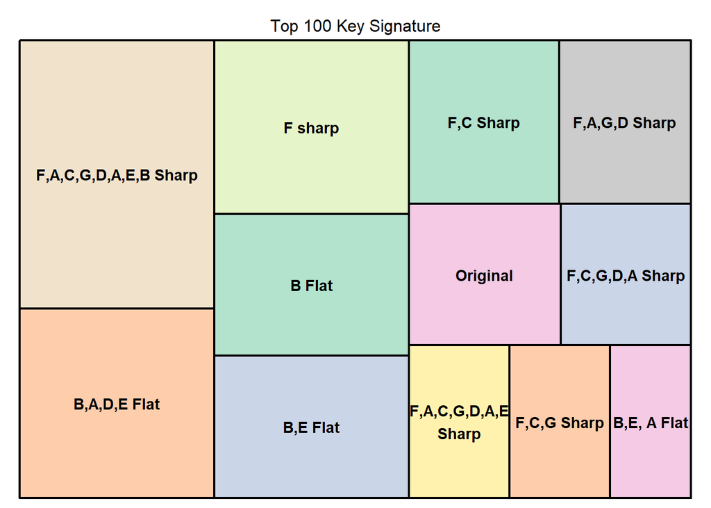

```r
# Key signature count
keys1 <- group_by(spotify_data, keysign )
keys2 <- dplyr::summarise(keys1,  count=n())
keys2 <- arrange(keys2, desc(count))

# key signiature treemap
treemap(keys2, index="keysign", vSize="count", type="index",
        palette="Pastel2", title="Top 100 Key Signature", fontsize.title=12)
```

# Rythme analysis {.tabset .tabset-fade .tabset-pills}

## Tempo Classification

Now we tak a look at what is the most popular Tempo type amont the top 100 songs, We will use the categorized tempo type to do the analysis. We can see about half of the songs has tempo between 76 to 108. So Andante is the most used tempo. Adagio is the least used tempo. I guess slow songs is not that popular then.

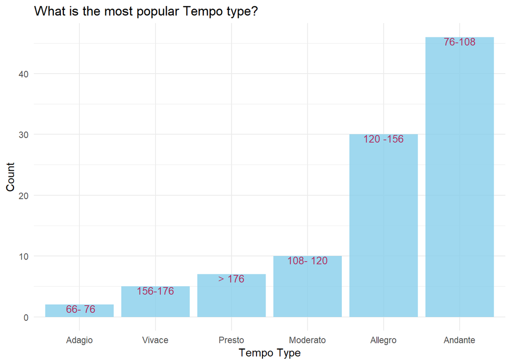

```r
tempo1 <- group_by(spotify_data, tempoc ,tlabel )
tempo2 <- dplyr::summarise(tempo1,  count=n())
tempo2 <- arrange(tempo2, desc(count))

tempop1<- ggplot(data=tempo2, aes(x=reorder(tempoc,count), y=count))+geom_bar(aes(y=count),stat="identity", alpha=0.8,fill="skyblue" )+ ylab("Count")+ xlab("Tempo Type")+ggtitle("What is the most popular Tempo type? ")+
  geom_text(aes(label=tlabel), vjust=1, color="maroon", size=3.5)+ theme_minimal()
tempop1
```

## general Tempo range

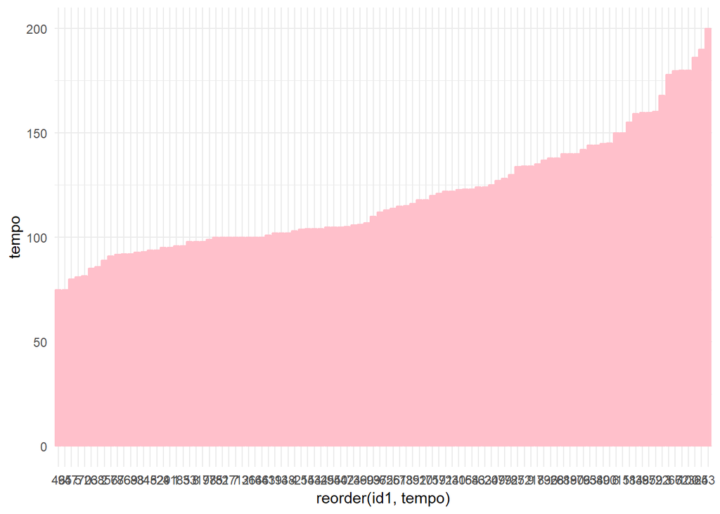

```r
spotify_data$id1=seq(1, nrow(spotify_data))

plot1 <- ggplot(spotify_data, aes(x=reorder(id1,tempo),y=tempo)) +geom_bar(stat = "identity", col = "pink", fill = "pink")+theme_minimal()
plot1
```

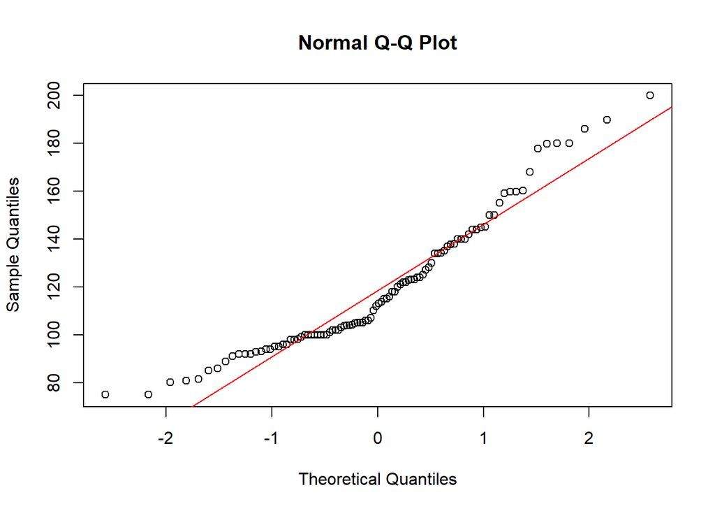

```r
qqnorm(spotify_data$tempo)
qqline(spotify_data$tempo, col="red")
```

# Categorical analysis on Key and Tempo

## Heatmap Valence respect to Key and Tempo

The songs showed the most valence with the Moderato tempo in C# major.

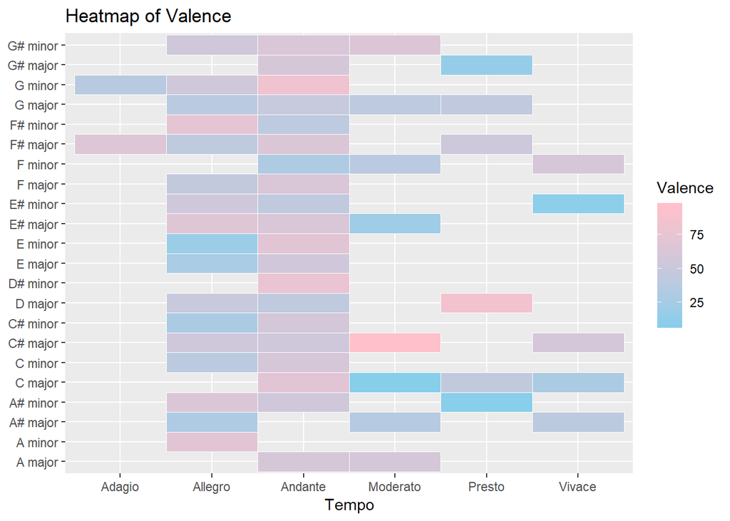

```r
vorig <- group_by(spotify_data, tempoc , keys)
vorig1 <- summarise(vorig,  count=n() ,rate= mean(valence))

 ggplot(vorig1, aes(x=tempoc, y=keys, fill = rate)) +
    geom_tile(colour = "white")  +
    scale_fill_gradient(low="skyblue", high="Pink") +
    labs(x="Tempo", y=NULL, title="Heatmap of Valence" ,fill="Valence")
```

## Heatmap Danceability respect to Key and Tempo

We can see from the Adagio and G minor give the most dance ability. We can try to dance with Bach Sonata No.1 in G minor, BWV 1001- Adagio at home.

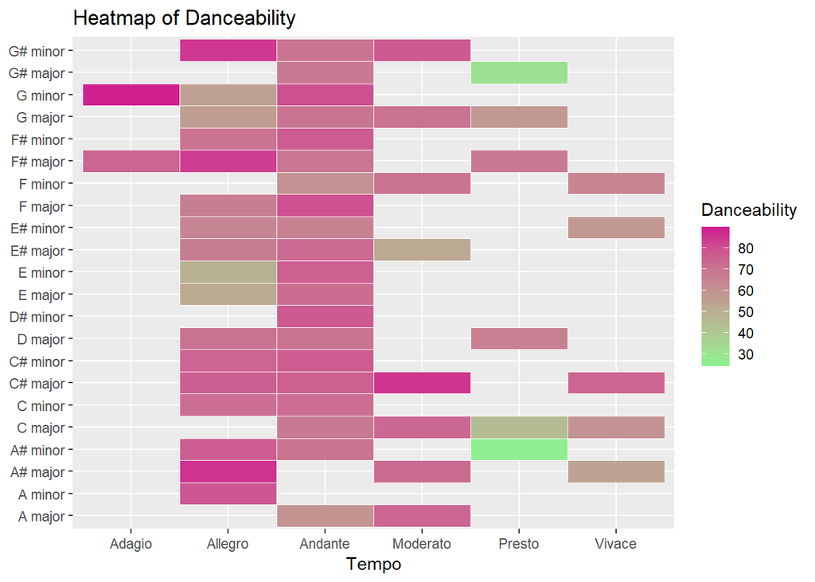

```r
orig <- group_by(spotify_data, tempoc , keys)
orig1 <- summarise(orig,  count=n() ,rate= mean(danceability))

 ggplot(orig1, aes(x=tempoc, y=keys, fill = rate)) +
    geom_tile(colour = "white")  +
    scale_fill_gradient(low="lightgreen", high="violetred") +
    labs(x="Tempo", y=NULL, title="Heatmap of Danceability" ,fill="Danceability")
```

## Heatmap Energy respect to Key and Tempo

we can see Vivace and A# major demonstrated high energy. I think higher speed will represent higher energy. However, we notice with Vivace and C# major, the energy is quite low. I think that’s because C# has grief depressive feeling

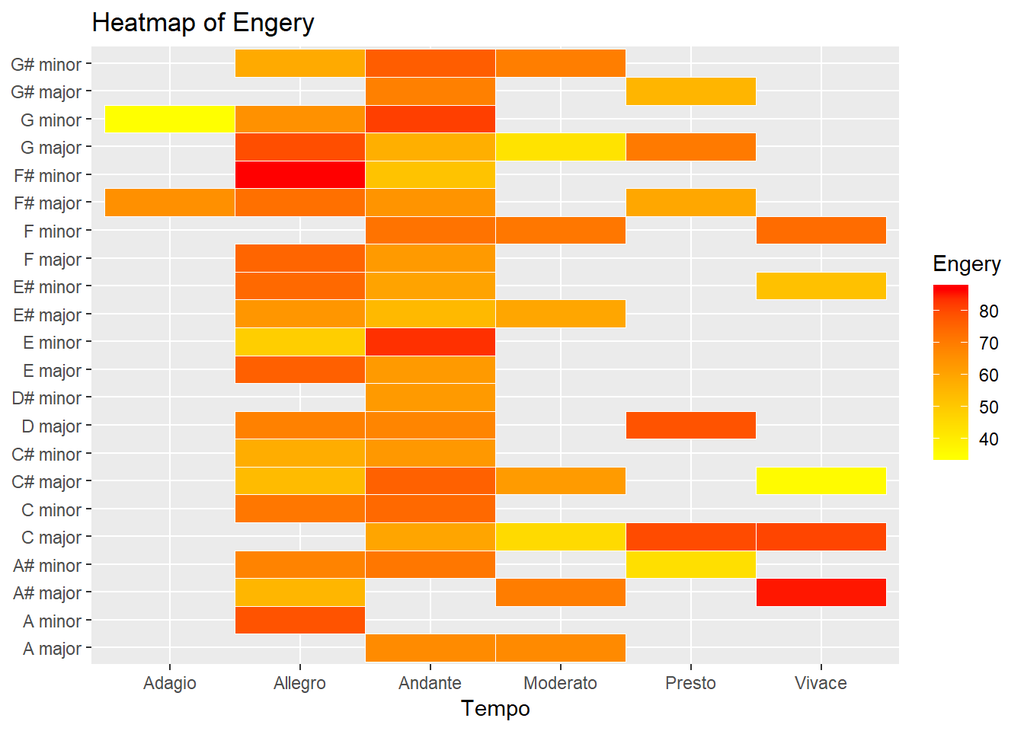

```r
eorig <- group_by(spotify_data, tempoc , keys)
eorig1 <- summarise(eorig,  count=n() ,rate= mean(energy))

 ggplot(eorig1, aes(x=tempoc, y=keys, fill = rate)) +
    geom_tile(colour = "white")  +
    scale_fill_gradient(low="yellow", high="red") +
    labs(x="Tempo", y=NULL, title="Heatmap of Engery" ,fill="Engery")
```

## Heatmap Speechiness respect to Key and Tempo

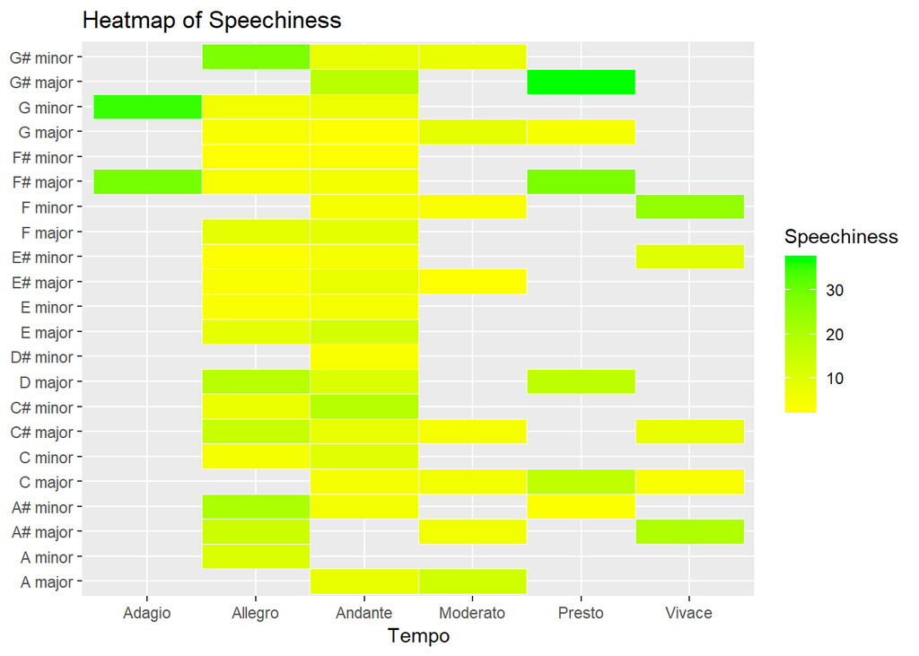

```r
 sorig <- group_by(spotify_data, tempoc , keys)
sorig1 <- summarise(eorig,  count=n() ,rate= mean(speechiness))

 ggplot(sorig1, aes(x=tempoc, y=keys, fill = rate)) +
    geom_tile(colour = "white")  +
    scale_fill_gradient(low="yellow", high="green") +
    labs(x="Tempo", y=NULL, title="Heatmap of Speechiness" ,fill="Speechiness")
```